# exFINDER: identify external communication signals using single-cell transcriptomics data

Changhan He

26 November, 2022

This vignette outlines the steps of applying exFINDER to zebrafish single-cell transcriptomics data on: (1) identifying external signals associated to the differentiation from earlyNC cells to skeletal and pigment cells; (2) inferring and analyzing the external signal-target signaling network (exSigNet); (3) visualizing the results.

## Load the required libraries

```r
library(exFINDER)
library(Seurat)
library(ggplot2)
library(patchwork)
library(RColorBrewer)
```

# Part I: Data input & processing & visualizing

exFINDER requires two user inputs: one is the gene expression data of cells, and the other is either user assigned cell labels.

*For the gene expression data matrix*, genes should be in rows with rownames and cells in columns with colnames. Normalized data is required as input for CellChat analysis.

```r
# load complete dataset with cell labels
# this dataset can be download from: https://figshare.com/s/2a674f8342abdf195fb6
Data1 <- readRDS("/Users/chang/Documents/exFINDER/testdata/Tatarakis2021_Zebrafish_Arch1_aggregate_unfiltered.RDS")
Data1@meta.data$Type <- as.factor(Data1@meta.data$guided_cell_type)

# load NC-cell dataset with cell labels
# this dataset can be download from: https://figshare.com/s/54cc0e83f734995d8d2e
Data2 <- readRDS("/Users/chang/Documents/exFINDER/testdata/Tatarakis2021_Zebrafish_Arch1_new_aggregate_filtered_noNT.RDS")
# this dataset can be download from: https://figshare.com/s/6538f43bf233abd9f288
celltypes <- as.factor( read.csv(file = '/Users/chang/Documents/exFINDER/testdata/Tatarakis2021_Zebrafish_Arch1_new_aggregate_filtered_noNT_celltypes.csv')[,2] )
Data2@meta.data$Type <- celltypes
```

```r
# select non-NC cells according to the paper: Tatarakis D et al. Cell reports, 2021, 37(12): 110140. (Fig. 1C)
Data1 <- subset(x = Data1, subset = (Type == "earlyNC" |
                                       Type == "Endothelium" |
                                       Type == "Epithelium" |
                                       Type == "Heart primordium"|
                                       Type ==  "neural_glial" |
                                       Type == "NT" |
                                       Type == "other" |
                                       Type == "pigment" |
                                       Type == "skeletal" |
                                       Type == "unassigned"))

# merge "other" and "unassigned" to "transition"
library(forcats)

Data1@meta.data$Type <- fct_collapse(Data1@meta.data$Type, "transition"=c("other","unassigned"))
Data1@meta.data$Type <- fct_collapse(Data1@meta.data$Type, "Heart_primordium"="Heart primordium")
Data1@meta.data$Type <- fct_drop(Data1@meta.data$Type)
Data2@meta.data$Type <- fct_collapse(Data2@meta.data$Type, "transition"=c("other","unassigned"))
```

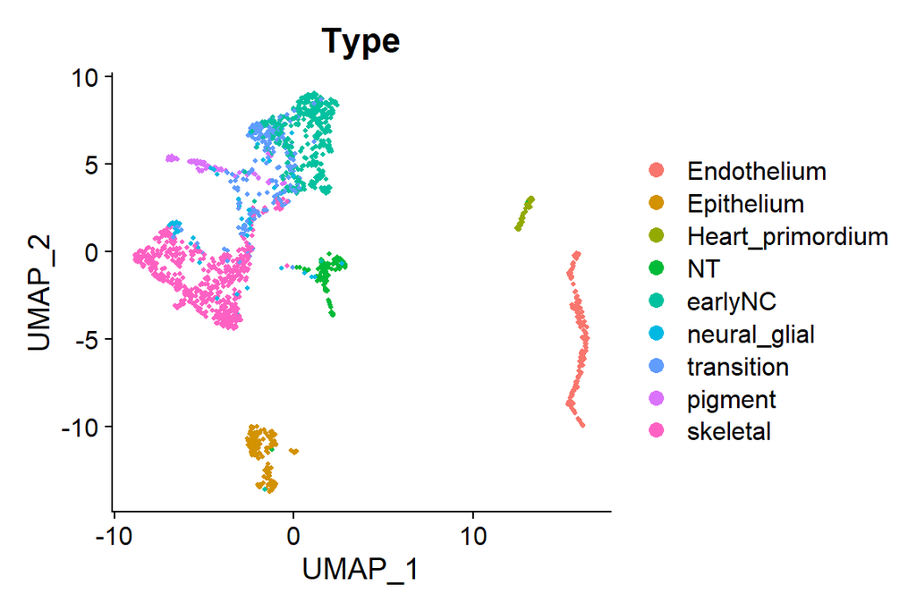

```r
# visualze the complete dataset
DimPlot(object = Data1, group.by = "Type", pt.size = 0.75)
```

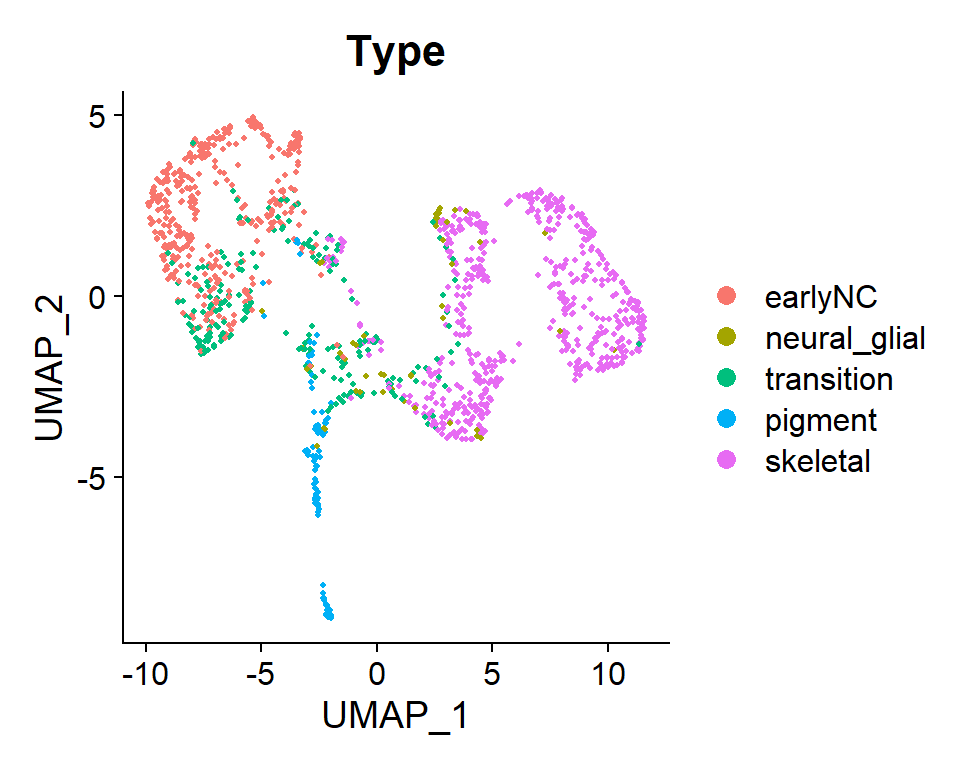

```r
# visualze the NC-cell dataset
DimPlot(object = Data2, group.by = "Type", pt.size = 0.75)
```

```r
# if needed, users can discover and save marker genes of each cluster by running this chunk (optional)

# Type <- levels(Data1@meta.data$Type)
# n <- length(Type)
# Data1.marker <- c()
#
# for (i in 1:n) {
#   cluster.markers <- FindMarkers(Data1,
#                                  ident.1 = Type[i] ,
#                                  group.by = "Type",
#                                  only.pos = TRUE,
#                                  min.pct = 0.25,
#                                  logfc.threshold = 0.25)
#
#   cluster.markers %>%
#     slice_max(order_by = -p_val)
#   cluster.markers <- cluster.markers[1:100,]
#
#   Data1.marker <- c(Data1.marker, rownames(cluster.markers[1:10, ]))
#
#   write.csv(x = cluster.markers , file = paste("markers_",Type[i],".csv",sep=""))
# }
```

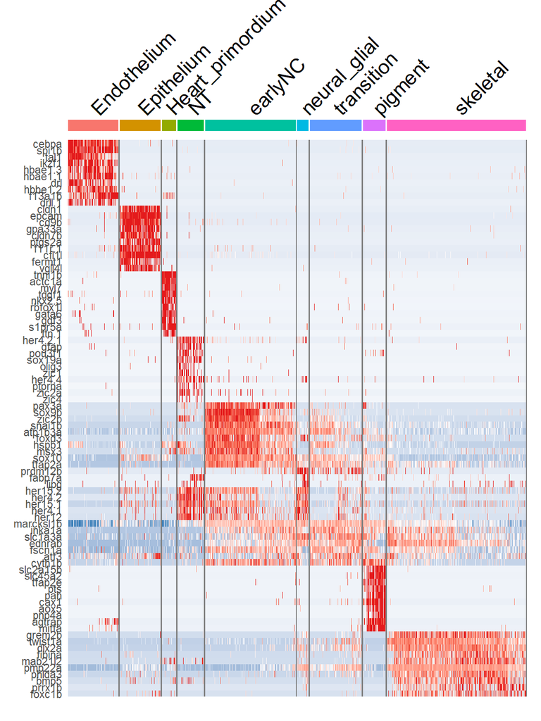

```r
# if all marker genes are saved, we can directly load and visualize
Type <- levels(Data1@meta.data$Type)
n <- length(Type)
Data1@active.ident <- Data1@meta.data$Type
Data1.marker <- c()

for (i in 1:n) {
  cluster.markers <- read.csv(file = paste("../markers/Tatarakis2021_Zebrafish_marker/Tatarakis2021_Zebrafish_markers_",Type[i],".csv",sep=""))

  cluster.markers <- cluster.markers$X[1:10]

  Data1.marker <- c(Data1.marker, cluster.markers)
}

DoHeatmap(Data1, features = Data1.marker) + NoLegend() +
  scale_fill_gradientn(colors = c("#377EB8", "white", "#E41A1C"))
```

## Part II: Loading exFINDER database (and optional ligand-receptor database)

*exFINDER database* is available for human, mouse, and zebrafish. *ligand-receptor database* is used for inferring functionally related signaling pathways from the exSigNet, here we use the ligand-receptor database from CellChat.

```r
# load exFINDER database
load("../data/LR_layer1_zebrafish.rda")
load("../data/RTF_layer2_zebrafish.rda")
load("../data/TFT_layer3_zebrafish.rda")

exFINDER.Z <- list()
exFINDER.Z[[1]] <- LR_layer1_zebrafish
exFINDER.Z[[2]] <- RTF_layer2_zebrafish
exFINDER.Z[[3]] <- TFT_layer3_zebrafish
```

```r
# load CellChatDB
# CellChatLR.human = load("../data/interaction_input_CellChatDB_human.rda")
# CellChatLR.mouse = load("../data/interaction_input_CellChatDB_mouse.rda")
load("../data/interaction_input_CellChatDB_zebrafish.rda")
```

## Prepare the inputs for exFINDER analysis

```r
exp.data <- Data2@assays$RNA@data
meta.data <- Data2@meta.data

# the complete dataset contains the data of non-NC cells, which are defined as "external cells"
exp.Exdata <- Data1@assays$RNA@data
meta.Exdata <- Data1@meta.data
```

# Part III: identifying external signals that come from NON-NC cells targeting skeletal cells

To identify differentiation-associated external signals, we select the marker genes of skeletal cells (one of the differentiated cell groups) as our target genes. However, the target genes *do not have to be* marker genes.

## setup target genes and infer ltGRN

```r
marker <- read.csv(file = "../markers/Tatarakis2021_Zebrafish_marker/Tatarakis2021_Zebrafish_markers_skeletal.csv")
target.gene <- marker$X[1:10]

ltGRN <- get_ltGRN(Target = target.gene, DB = exFINDER.Z)
```

## identify external signals and infer exSigNet

```r
# infer potential external signals from ltGRN
Pex <- get_potentialex(Graph = ltGRN,
                Exp.Data = exp.data,
                Meta.Data = meta.data,
                cutoff = -0.15,
                AG.L = NULL)
head(Pex)
```

```
#> [1] "l1cama" "cntn2"  "ncam1a" "ptprfb" "tnfa"   "tnfb"
```

```r
# infer exSigNet (R, TF, T are all highly expressed, L comes from the potential external signals)
exSigNet <- get_exSigNet(Graph = ltGRN,
                       Ligands = Pex,
                       Exp.Data = exp.data,
                       Meta.Data = meta.data,
                       par.cutoff = c(2, 2),
                       AG.R = c("skeletal", "transition"),
                       AG.TF = c('skeletal'))
```

```
#> [1] "No overlap found!"
```

```r
exSigNet
```

```
#> $Graph.Edge
#>              from      to   source                 path from.Role  to.Role
#> 1           pros1    rpsa NicheNet           pros1*rpsa    Ligand Receptor
#> 2      zgc:153044    rpsa NicheNet      zgc:153044*rpsa    Ligand Receptor
#> 3          calm3a    rpsa NicheNet          calm3a*rpsa    Ligand Receptor
#> 4            fn1a    rpsa NicheNet            fn1a*rpsa    Ligand Receptor
#> 5        col12a1b    rpsa NicheNet        col12a1b*rpsa    Ligand Receptor
#> 6           lamb2    rpsa NicheNet           lamb2*rpsa    Ligand Receptor
#> 7          vcam1b    rpsa NicheNet          vcam1b*rpsa    Ligand Receptor
#> 8            fn1b    rpsa NicheNet            fn1b*rpsa    Ligand Receptor
#> 9  CABZ01041494.1   rps19   IUPHAR CABZ01041494.1*rps19    Ligand Receptor
#> 10         ptprfb   rack1 NicheNet         ptprfb*rack1    Ligand Receptor
#> 11         itgb1a   rack1 NicheNet         itgb1a*rack1    Ligand Receptor
#> 12            ret   rack1 NicheNet            ret*rack1    Ligand Receptor
#> 13           tnfa   rack1 NicheNet           tnfa*rack1    Ligand Receptor
```

[output cut: 96 more lines]

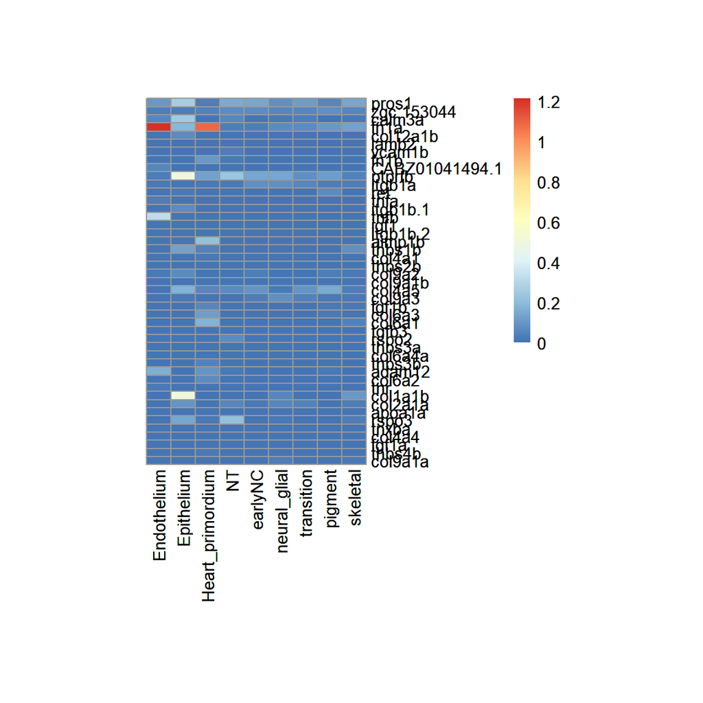

```r
# check the inferred external signals and their expressions via heatmap
exS <- exSigNet$Graph.Node$Gene[exSigNet$Graph.Node$Role == "Ligand"]

get_heatmap(Gene = exS,
            Exp.Data = exp.Exdata,
            Meta.Data = meta.Exdata)
```

```r
# select the external signals that expressed by non-NC cells and infer the corresponding exSigNet
exSigNet <- get_exSigNetExData(Graph = exSigNet,
                                 Exp.ExData = exp.Exdata,
                                 Meta.ExData = meta.Exdata,
                                 cutoff.ExData = 0.5,
                                 AG.ExData = c('Endothelium','Epithelium','Heart_primordium','NT'))
```

```
#> [1] "No overlap found!"
```

```r
exSigNet
```

```
#> $Graph.Edge
#>      from      to   source         path from.Role  to.Role
#> 1    fn1a    rpsa NicheNet    fn1a*rpsa    Ligand Receptor
#> 2    fn1a    sdc4 CellChat    fn1a*sdc4    Ligand Receptor
#> 3 col1a1b    sdc4 CellChat col1a1b*sdc4    Ligand Receptor
#> 4    rpsa    ybx1 NicheNet    rpsa*ybx1  Receptor       TF
#> 5    sdc4    ybx1 NicheNet    sdc4*ybx1  Receptor       TF
#> 6    ybx1 twist1a NicheNet ybx1*twist1a        TF   Target
#> 7    ybx1  foxc1b NicheNet  ybx1*foxc1b        TF   Target
#>
#> $Graph.Node
#>      Gene     Role
#> 1    fn1a   Ligand
#> 2 col1a1b   Ligand
#> 3    rpsa Receptor
#> 4    sdc4 Receptor
#> 5    ybx1       TF
#> 6 twist1a   Target
#> 7  foxc1b   Target
```

```r
# calculate the expression levels
exSigNet <- get_NodeValue(Graph = exSigNet,
                          Exp.Data = exp.Exdata,
                          Meta.Data = meta.Exdata,
                          AG.R = c("skeletal", "transition"),
                          AG.TF = c('skeletal'),
                          AG.T = c('skeletal'),
                          Exp.ExData = NULL,
                          Meta.ExData = NULL,
                          AG.ExData = NULL)

# predict signaling strengths
exSigNet <- get_EdgeWeight(Graph = exSigNet,
               Kh = 2)
```

### visualize the exSigNet via heatmap plot

```r
# prepare the dataframe for heatmap plot
exS_exp <- get_AveExp(Gene = exSigNet$Graph.Node$Gene,
           Exp.Data = exp.Exdata,
           Meta.Data = meta.Exdata)

exS_exp.HP <- exS_exp
exS_exp.HP <- exS_exp.HP[, -1]
row.names(exS_exp.HP) <- exS_exp$Gene

exS_exp.HP <- data.frame("Endothelium" = exS_exp.HP$Endothelium,
                     "Epithelium" = exS_exp.HP$Epithelium, 'Heart_primordium' = exS_exp.HP$`Heart_primordium`,
                     "NT" = exS_exp.HP$NT,
                     "earlyNC" = exS_exp.HP$earlyNC, "transition" = exS_exp.HP$transition,
                     "neural_glial" = exS_exp.HP$neural_glial,
                     "pigment" = exS_exp.HP$pigment, "skeletal" = exS_exp.HP$skeletal)
row.names(exS_exp.HP) <- exS_exp$Gene

exS_exp.HP
```

```
#>         Endothelium Epithelium Heart_primordium         NT     earlyNC
#> fn1a     1.21183418 0.18464225       1.08014500 0.02815706 0.033534543
#> col1a1b  0.00000000 0.50777178       0.00000000 0.00000000 0.002064398
#> rpsa     3.92608803 4.02305825       3.89513199 4.05923462 4.004826447
#> sdc4     0.57257818 1.53447024       1.23869609 0.87685693 0.573955733
#> ybx1     3.86988673 4.04941482       3.69826125 3.76516838 4.019058728
#> twist1a  0.03729652 0.03614891       0.40188468 0.02636362 0.279589801
#> foxc1b   0.00797788 0.14420164       0.03593282 0.02109347 0.005446412
#>          transition neural_glial     pigment  skeletal
#> fn1a    0.067890457   0.06858420 0.098075301 0.1267744
#> col1a1b 0.003382779   0.04962805 0.000000000 0.1007590
#> rpsa    4.107854960   4.18502613 4.084060032 4.1249964
#> sdc4    0.931916355   1.47701850 1.460007649 2.0038895
#> ybx1    3.789713993   3.77439351 3.570908640 3.7458862
#> twist1a 1.020610328   0.56194262 0.017746461 2.4950608
#> foxc1b  0.042992225   0.02795225 0.006154325 0.6020057
```

```r
# customize the row labels and col labels
annotation_col = data.frame(
  CellType = c("non-NC cell", "non-NC cell", "non-NC cell", "non-NC cell", "NC cell", "NC cell", "NC cell", "NC cell", "NC cell"))
rownames(annotation_col) = colnames(exS_exp.HP)

annotation_row <- data.frame(Role = exSigNet$Graph.Node$Role)
row.names(annotation_row) <- row.names(exS_exp.HP)
```

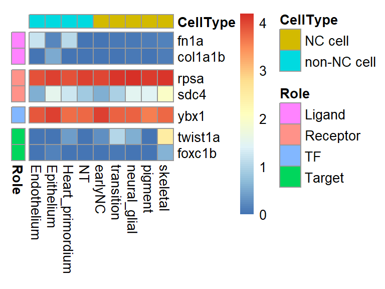

```r
# heatmap plot
library(pheatmap)

pheatmap(exS_exp.HP,
         cluster_row = FALSE, cluster_cols = FALSE,
         cellwidth = 12, cellheight = 12,
         gaps_row = c(2, 4, 5),
         fontsize_row = 10,
         fontsize_col = 10,
         annotation_row = annotation_row,
         annotation_col = annotation_col)
```

### visualize the exSigNet via hierarchy plot

```r
# prepare for hierarchy plot
Graph <- exSigNet

hierarchy <- data.frame(from="origin", to=Graph$Graph.Node$Gene)
all_leaves <- Graph$Graph.Node$Gene

connect <- data.frame(from = Graph$Graph.Edge$from, to = Graph$Graph.Edge$to)
connect$value <- Graph$Graph.Edge$Weight

vertices <- data.frame(name = unique(c(as.character(hierarchy$from), as.character(hierarchy$to))),
                       Expression = c(0, Graph$Graph.Node$Size))
vertices$node <- c(" ", Graph$Graph.Node$Gene)
vertices$Role <- c("NA", Graph$Graph.Node$Role)

mygraph <- igraph::graph_from_data_frame( hierarchy, vertices=vertices )

from <- match( connect$from, vertices$name)
to <- match( connect$to, vertices$name)
weight <- connect$value
```

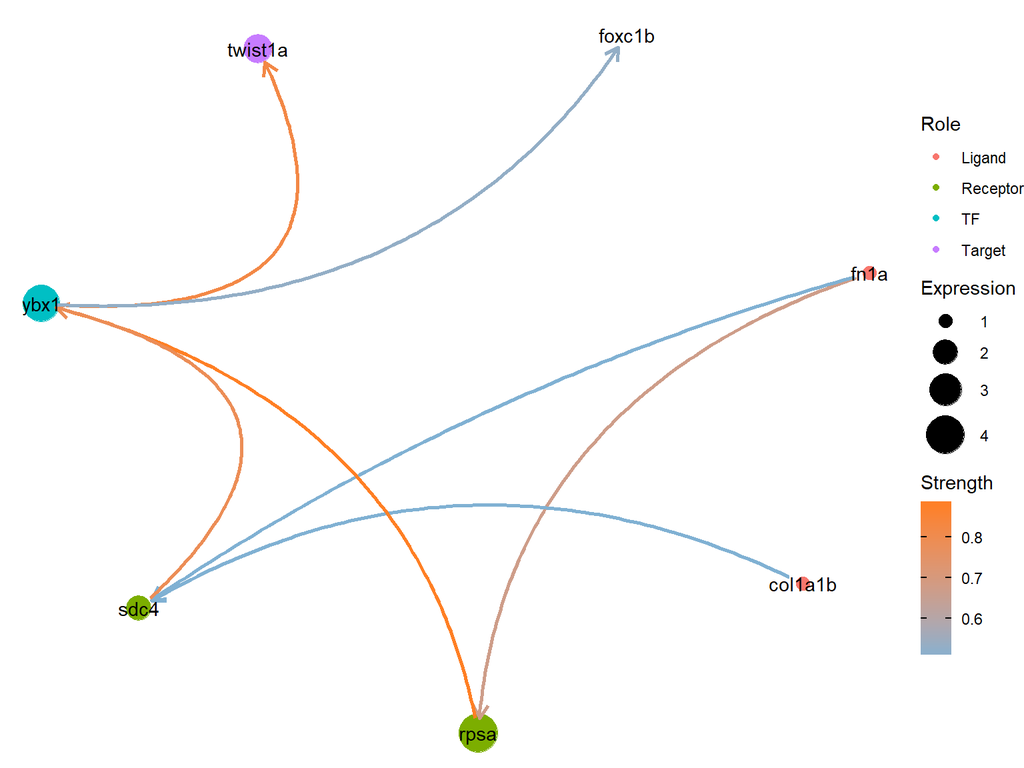

```r
# hierarchy plot
library(ggraph)

ggraph(mygraph, layout = 'dendrogram', circular = TRUE) +
  geom_node_point(aes(filter = leaf, x=x, y=y, colour=Role, size=Expression)) +
  theme_void() +
  geom_conn_bundle(data = get_con(from = from, to = to, Strength = weight), width = 1.0, aes(colour=Strength),
                   arrow = arrow(length = unit(3, 'mm')), start_cap = circle(3, 'mm'), end_cap = circle(3, 'mm')) +
  scale_edge_color_continuous(low="#80b1d3", high="#FF7F24")+
  geom_node_text(aes(label = node)) +
  scale_size_continuous( range = c(0.1,10) )
```

# Part IV: identifying external signals that come from external environment targeting skeletal cells

Here, *come from external environment* means very low (or zero) expressions in the measured cells (NC and non-NC cells).

## setup target genes and infer ltGRN

```r
marker <- read.csv(file = "../markers/Tatarakis2021_Zebrafish_marker/Tatarakis2021_Zebrafish_markers_skeletal.csv")
target.gene2 <- marker$X[11:20]

ltGRN.2 <- get_ltGRN(Target = target.gene2, DB = exFINDER.Z)
```

## identify external signals and infer exSigNet

```r
# infer potential external signals from ltGRN.2: low expression in measured cells
Pex.2 <- get_potentialex(Graph = ltGRN.2,
                Exp.Data = exp.Exdata,
                Meta.Data = meta.Exdata,
                cutoff = -0.15,
                AG.L = NULL)
head(Pex.2)
```

```
#> [1] "l1cama" "cntn2"  "ncam1a" "tnfa"   "kng1"   "penkb"
```

```r
# infer exSigNet.2 (R, TF, T are all highly expressed, L comes from the potential external signals)
exSigNet.2 <- get_exSigNet(Graph = ltGRN.2,
                       Ligands = Pex.2,
                       Exp.Data = exp.data,
                       Meta.Data = meta.data,
                       par.cutoff = c(1, 1),
                       AG.R = c("skeletal", "transition"),
                       AG.TF = c('skeletal'))
```

```
#> [1] "No overlap found!"
```

```r
# exSigNet.2
```

```r
# based on this "exSigNet.2", we identify the receptors that only activated by these external signals
exSigNet.2 <- filterLR_exSigNet(Graph = exSigNet.2,
                  Exp.Data = exp.Exdata,
                  DB = exFINDER.Z)
```

```
#> [1] "No overlap found!"
```

```r
# exSigNet.2
```

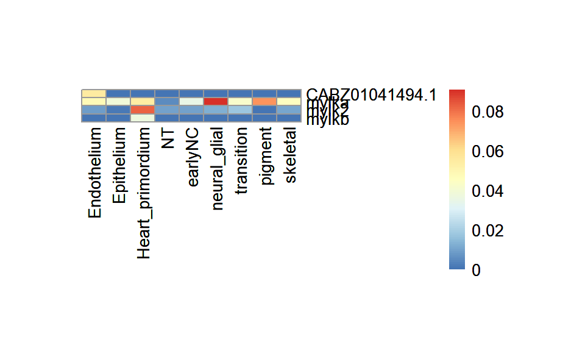

```r
# check the inferred external signals and their expressions via heatmap
exS.2 <- exSigNet.2$Graph.Node$Gene[exSigNet.2$Graph.Node$Role == "Ligand"]

get_heatmap(Gene = exS.2,
            Exp.Data = exp.Exdata,
            Meta.Data = meta.Exdata)
```

```r
# calculate the expression levels
exSigNet.2 <- get_NodeValue(Graph = exSigNet.2,
                          Exp.Data = exp.Exdata,
                          Meta.Data = meta.Exdata,
                          AG.R = c("skeletal", "transition"),
                          AG.TF = c('skeletal'),
                          AG.T = c('skeletal'),
                          Exp.ExData = NULL,
                          Meta.ExData = NULL,
                          AG.ExData = NULL)

# predict signaling strengths
exSigNet.2 <- get_EdgeWeight(Graph = exSigNet.2,
               Kh = 2)
```

### visualize the exSigNet via heatmap plot

```r
# prepare the dataframe for heatmap plot
exS.2_exp <- get_AveExp(Gene = exSigNet.2$Graph.Node$Gene,
           Exp.Data = exp.Exdata,
           Meta.Data = meta.Exdata)


exS.2_exp.HP <- exS.2_exp
exS.2_exp.HP <- exS.2_exp.HP[, -1]
row.names(exS.2_exp.HP) <- exS.2_exp$Gene
exS.2_exp.HP
```

```
#>                Endothelium  Epithelium Heart_primordium          NT     earlyNC
#> CABZ01041494.1 0.054816478 0.000000000       0.00000000 0.000000000 0.000000000
#> mylka          0.047235722 0.038727956       0.05419737 0.004748958 0.034921200
#> mylk2          0.009033494 0.001743428       0.08172644 0.009881997 0.009932999
#> mylkb          0.000000000 0.000000000       0.03683381 0.000000000 0.000000000
#> rps19          4.208631554 4.268834954       4.21635252 4.143118033 4.076497965
#> calm3b         1.469567422 1.551283839       1.27328104 1.586945942 1.469537606
#> ybx1           3.869886733 4.049414820       3.69826125 3.765168381 4.019058728
#> rad21a         0.741769233 0.902708946       0.70621151 1.040268446 0.988534468
#> ewsr1a         0.663127062 0.810784465       0.92099246 1.004017733 0.912929411
#> ewsr1b         0.941331327 1.416520760       1.12181404 1.575766698 1.314250876
#> smarca4a       0.894549558 0.915915159       0.94946599 1.097678635 1.239781932
#> stmn1a         0.417324582 1.389386607       0.32664617 1.475128452 0.401262862
#> dlx3b          0.000000000 0.206554002       0.01986583 0.026760942 0.053955525
#> twist3         0.002737764 0.000000000       0.00000000 0.012061828 0.000000000
#> foxd1          0.000000000 0.000000000       0.01201583 0.061249996 0.005284498
#> pcbd1          0.075205741 0.194162387       0.03686089 0.174278555 0.180788142
#> prrx1a         0.001478227 0.031854181       0.43071570 0.013009087 0.058857822
#> tuba8l3        0.117762257 0.072764456       0.53306856 0.332913209 0.201134734
#> dlx4b          0.000000000 0.032046969       0.00000000 0.003578354 0.007492472
#> cthrc1a        0.007110961 0.000000000       0.02487210 0.049883659 0.003892269
#>                neural_glial transition     pigment   skeletal
#> CABZ01041494.1   0.00000000 0.00000000 0.000000000 0.00000000
#> mylka            0.09060151 0.04195205 0.073814384 0.04508111
#> mylk2            0.01199040 0.01726865 0.000000000 0.01043601
#> mylkb            0.00000000 0.00000000 0.000000000 0.00000000
#> rps19            4.23700395 4.20767568 4.158182938 4.13071703
#> calm3b           1.61113241 1.55057258 1.426852051 1.80577662
#> ybx1             3.77439351 3.78971399 3.570908640 3.74588617
#> rad21a           0.95903521 0.85539052 0.767153920 1.11190543
#> ewsr1a           1.01408213 0.77892291 0.853365276 1.17155445
#> ewsr1b           1.48518300 1.14694593 1.409401880 1.64997970
#> smarca4a         0.84499235 1.05375053 0.754325449 1.03731061
#> stmn1a           1.89001795 1.13271217 0.327436635 2.29161263
#> dlx3b            0.02077015 0.02324444 0.014720154 1.17177368
#> twist3           0.04511720 0.00889285 0.000000000 0.41762555
#> foxd1            0.04950121 0.04684909 0.000000000 0.55395107
#> pcbd1            1.11247351 0.51165567 1.632770308 1.27251707
#> prrx1a           0.21253331 0.17416542 0.007589826 0.68174619
#> tuba8l3          1.62172617 0.85747819 1.234211519 1.57750789
#> dlx4b            0.01199040 0.00000000 0.000000000 0.72831421
#> cthrc1a          0.11984525 0.03666982 0.019642072 0.48357206
```

```r
exS.2_exp.HP <- data.frame("Endothelium" = exS.2_exp.HP$Endothelium,
                     "Epithelium" = exS.2_exp.HP$Epithelium, 'Heart_primordium' = exS.2_exp.HP$`Heart_primordium`,
                     "NT" = exS.2_exp.HP$NT,
                     "earlyNC" = exS.2_exp.HP$earlyNC, "transition" = exS.2_exp.HP$transition,
                     "neural_glial" = exS.2_exp.HP$neural_glial,
                     "pigment" = exS.2_exp.HP$pigment, "skeletal" = exS.2_exp.HP$skeletal)
row.names(exS.2_exp.HP) <- exS.2_exp$Gene

exS.2_exp.HP
```

```
#>                Endothelium  Epithelium Heart_primordium          NT     earlyNC
#> CABZ01041494.1 0.054816478 0.000000000       0.00000000 0.000000000 0.000000000
#> mylka          0.047235722 0.038727956       0.05419737 0.004748958 0.034921200
#> mylk2          0.009033494 0.001743428       0.08172644 0.009881997 0.009932999
#> mylkb          0.000000000 0.000000000       0.03683381 0.000000000 0.000000000
#> rps19          4.208631554 4.268834954       4.21635252 4.143118033 4.076497965
#> calm3b         1.469567422 1.551283839       1.27328104 1.586945942 1.469537606
#> ybx1           3.869886733 4.049414820       3.69826125 3.765168381 4.019058728
#> rad21a         0.741769233 0.902708946       0.70621151 1.040268446 0.988534468
#> ewsr1a         0.663127062 0.810784465       0.92099246 1.004017733 0.912929411
#> ewsr1b         0.941331327 1.416520760       1.12181404 1.575766698 1.314250876
#> smarca4a       0.894549558 0.915915159       0.94946599 1.097678635 1.239781932
#> stmn1a         0.417324582 1.389386607       0.32664617 1.475128452 0.401262862
#> dlx3b          0.000000000 0.206554002       0.01986583 0.026760942 0.053955525
#> twist3         0.002737764 0.000000000       0.00000000 0.012061828 0.000000000
#> foxd1          0.000000000 0.000000000       0.01201583 0.061249996 0.005284498
#> pcbd1          0.075205741 0.194162387       0.03686089 0.174278555 0.180788142
#> prrx1a         0.001478227 0.031854181       0.43071570 0.013009087 0.058857822
#> tuba8l3        0.117762257 0.072764456       0.53306856 0.332913209 0.201134734
#> dlx4b          0.000000000 0.032046969       0.00000000 0.003578354 0.007492472
#> cthrc1a        0.007110961 0.000000000       0.02487210 0.049883659 0.003892269
#>                transition neural_glial     pigment   skeletal
#> CABZ01041494.1 0.00000000   0.00000000 0.000000000 0.00000000
#> mylka          0.04195205   0.09060151 0.073814384 0.04508111
#> mylk2          0.01726865   0.01199040 0.000000000 0.01043601
#> mylkb          0.00000000   0.00000000 0.000000000 0.00000000
#> rps19          4.20767568   4.23700395 4.158182938 4.13071703
#> calm3b         1.55057258   1.61113241 1.426852051 1.80577662
#> ybx1           3.78971399   3.77439351 3.570908640 3.74588617
#> rad21a         0.85539052   0.95903521 0.767153920 1.11190543
#> ewsr1a         0.77892291   1.01408213 0.853365276 1.17155445
#> ewsr1b         1.14694593   1.48518300 1.409401880 1.64997970
#> smarca4a       1.05375053   0.84499235 0.754325449 1.03731061
#> stmn1a         1.13271217   1.89001795 0.327436635 2.29161263
#> dlx3b          0.02324444   0.02077015 0.014720154 1.17177368
#> twist3         0.00889285   0.04511720 0.000000000 0.41762555
#> foxd1          0.04684909   0.04950121 0.000000000 0.55395107
#> pcbd1          0.51165567   1.11247351 1.632770308 1.27251707
#> prrx1a         0.17416542   0.21253331 0.007589826 0.68174619
#> tuba8l3        0.85747819   1.62172617 1.234211519 1.57750789
#> dlx4b          0.00000000   0.01199040 0.000000000 0.72831421
#> cthrc1a        0.03666982   0.11984525 0.019642072 0.48357206
```

```r
# customize the row labels and col labels
annotation_col = data.frame(
  CellType = c("non-NC cell", "non-NC cell", "non-NC cell", "non-NC cell", "NC cell", "NC cell", "NC cell", "NC cell", "NC cell"))
rownames(annotation_col) = colnames(exS.2_exp.HP)

annotation_row <- data.frame(Role = exSigNet.2$Graph.Node$Role)
row.names(annotation_row) <- row.names(exS.2_exp.HP)
```

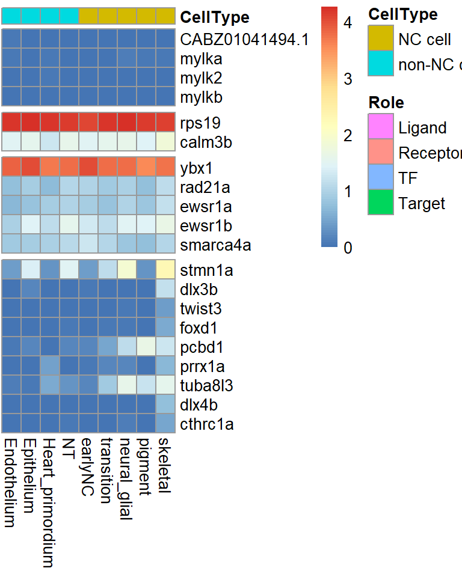

```r
# heatmap plot
library(pheatmap)

pheatmap(exS.2_exp.HP,
         cluster_row = FALSE, cluster_cols = FALSE,
         cellwidth = 12, cellheight = 12,
         gaps_row = c(4, 6, 11),
         fontsize_row = 10,
         fontsize_col = 10,
         annotation_row = annotation_row,
         annotation_col = annotation_col)
```

### visualize the exSigNet via hierarchy plot

```r
# prepare for hierarchy plot
Graph <- exSigNet.2

hierarchy <- data.frame(from="origin", to=Graph$Graph.Node$Gene)
all_leaves <- Graph$Graph.Node$Gene

connect <- data.frame(from = Graph$Graph.Edge$from, to = Graph$Graph.Edge$to)
connect$value <- Graph$Graph.Edge$Weight

vertices <- data.frame(name = unique(c(as.character(hierarchy$from), as.character(hierarchy$to))),
                       Expression = c(0, Graph$Graph.Node$Size))
vertices$node <- c(" ", Graph$Graph.Node$Gene)
vertices$Role <- c("NA", Graph$Graph.Node$Role)

mygraph <- igraph::graph_from_data_frame( hierarchy, vertices=vertices )

from <- match( connect$from, vertices$name)
to <- match( connect$to, vertices$name)
weight <- connect$value
```

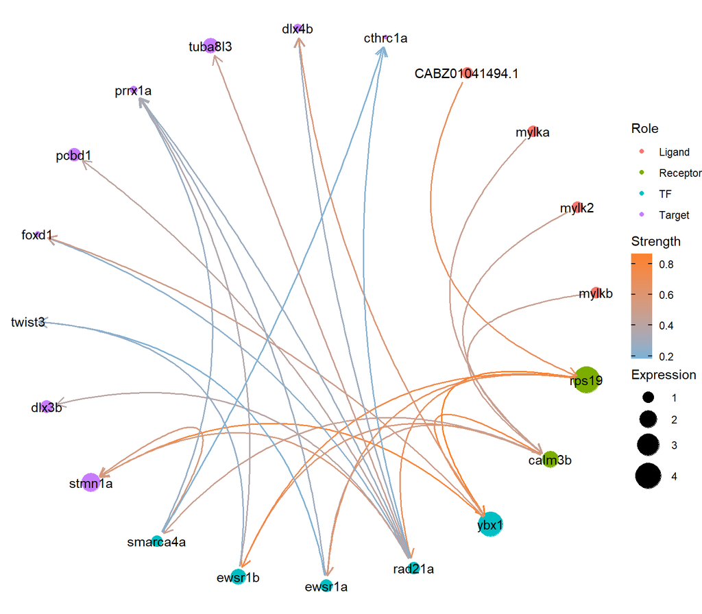

```r
# hierarchy plot
ggraph(mygraph, layout = 'dendrogram', circular = TRUE) +
  geom_node_point(aes(filter = leaf, x=x, y=y, colour=Role, size=Expression)) +
  theme_void() +
  geom_conn_bundle(data = get_con(from = from, to = to, Strength = weight), width = 0.7, aes(colour=Strength),
                   arrow = arrow(length = unit(3, 'mm')), start_cap = circle(3, 'mm'), end_cap = circle(3, 'mm')) +
  scale_edge_color_continuous(low="#80b1d3", high="#FF7F24")+
  geom_node_text(aes(label = node)) +
  scale_size_continuous( range = c(0.1,10) )
```

# Part IV: infer the critical transition signal-related exSigNet

*critical transition signals (CTS)* refer to a group of transcription factors (TFs) that drive the critial transition. Here we infer the exSigNet that: (1) activated by the ligands that come from ecternal environment; (2) the TFs are critical transition signals; (3) the target genes are marker genes of skeletal and pigment cells.

## load CTS and set-up target genes

```r
CTS.Z <- read.csv(file = "/Users/chang/Documents/exFINDER/testdata/Tatarakis2021_Zebrafish_CTS.csv")

markerS <- read.csv(file = "../markers/Tatarakis2021_Zebrafish_marker/Tatarakis2021_Zebrafish_markers_skeletal.csv")
markerP <- read.csv(file = "../markers/Tatarakis2021_Zebrafish_marker/Tatarakis2021_Zebrafish_markers_pigment.csv")
target.SP <- c(markerS$X[1:5], markerP$X[1:5])
```

## infer exSigNet (denoted as exSigNet.4)

```r
# infer ltGRN
ltGRN.3 <- get_ltGRN(Target = target.SP, DB = exFINDER.Z)
```

```r
# infer potential external signals from ltGRN
Pex.3 <- get_potentialex(Graph = ltGRN.3,
                Exp.Data = exp.Exdata,
                Meta.Data = meta.Exdata,
                cutoff = -0.01,
                AG.L = NULL)

# infer exSigNet (R, TF, T are all highly expressed, L comes from the potential external signals)
exSigNet.3 <- get_exSigNet(Graph = ltGRN.3,
                       Ligands = Pex.3,
                       Exp.Data = exp.data,
                       Meta.Data = meta.data,
                       par.cutoff = c(0.5, 0.01),
                       AG.R = c("skeletal", "transition", "pigment"),
                       AG.TF = c("skeletal", "transition", "pigment"))
```

```
#> [1] "No overlap found!"
```

```r
# if overlap is detected in an exSigNet, we shall fix it by running "fix_Overlap"
exSigNet.3 <- fix_OverLap(exSigNet.3)
```

```
#> [1] "No overlap found!"
```

```r
# check what CTS are inferred in the exSigNet
intersect(exSigNet.3$Graph.Node$Gene[exSigNet.3$Graph.Node$Role == "TF"], CTS.Z$x)
```

```
#> [1] "tal1" "lmo2"
```

```r
# infer the exSigNet that all TFs are CTS by running "get_subNet"
exSigNet.4 <- get_subNet(Graph = exSigNet.3,
           TF = c("tal1", "lmo2"))
exSigNet.4
```

```
#> $Graph.Edge
#>        from      to   source           path from.Role  to.Role
#> 1      igf1   rack1 NicheNet     igf1*rack1    Ligand Receptor
#> 2  itgb1b.2   rack1 NicheNet itgb1b.2*rack1    Ligand Receptor
#> 3     gdnfa  agtrap NicheNet   gdnfa*agtrap    Ligand Receptor
#> 4     rack1    tal1 NicheNet     rack1*tal1  Receptor       TF
#> 5    agtrap    lmo2 NicheNet    agtrap*lmo2  Receptor       TF
#> 6      tal1 slc45a2 NicheNet   tal1*slc45a2        TF   Target
#> 7      tal1 twist1a NicheNet   tal1*twist1a        TF   Target
#> 8      lmo2  fibina NicheNet    lmo2*fibina        TF   Target
#> 9      lmo2     pts NicheNet       lmo2*pts        TF   Target
#> 10     tal1   dlx2a NicheNet     tal1*dlx2a        TF   Target
#>
#> $Graph.Node
#>         Gene     Role
#> 4       igf1   Ligand
#> 5   itgb1b.2   Ligand
#> 21     gdnfa   Ligand
#> 25     rack1 Receptor
#> 30    agtrap Receptor
#> 71      tal1       TF
#> 146     lmo2       TF
#> 148  slc45a2   Target
#> 152  twist1a   Target
#> 153   fibina   Target
#> 154      pts   Target
#> 156    dlx2a   Target
```

## visualization

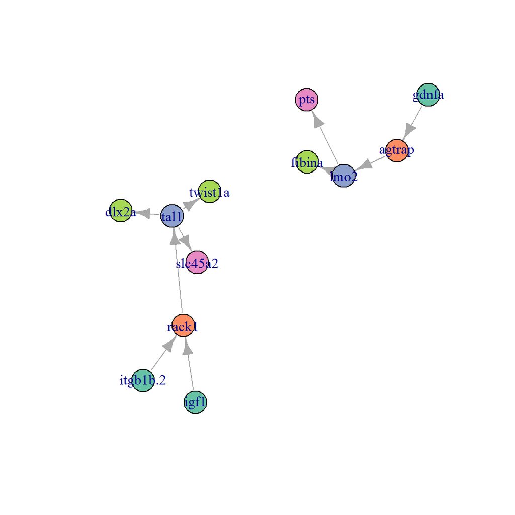

```r
library(igraph)
library(RColorBrewer)

exSigNet.4$Graph.Node$Role[exSigNet.4$Graph.Node$Gene %in% c("slc45a2", "pts")] = "Target (pigment)"
exSigNet.4$Graph.Node$Role[exSigNet.4$Graph.Node$Gene %in% c("twist1a", "fibina", "dlx2a")] = "Target (skeletal)"

actors <- data.frame(
  name = exSigNet.4$Graph.Node$Gene,
  role = exSigNet.4$Graph.Node$Role
)

relations <- data.frame(
  from = exSigNet.4$Graph.Edge$from,
  to = exSigNet.4$Graph.Edge$to
)

g <- graph_from_data_frame(
  relations, directed = TRUE,
  vertices = actors
)

l <- layout_with_gem(g)

coul  <- brewer.pal(5, "Set2")
# Create a vector of color
my_color <- coul[as.numeric(as.factor(V(g)$role))]

# pdf("CTS_Z_Network.pdf")
plot(g, layout=l, vertex.color=my_color)
```